# Final project of Practical Machine Learning course

Delia-Lisa Feis

16 Dezember 2017

# Background

Human Activity Recognition **- HAR -** has emerged as a key research area in the last years and is gaining increasing attention by the pervasive computing research community, especially for the development of context-aware systems. Using the dataset for this course project, my goal will be to use data from accelerometers on the belt, forearm, arm, and dumbell of 6 healthy male participants. They were asked to perform barbell lifts correctly and incorrectly in 5 different ways, i.e., exactly according to the specification (Class A), throwing the elbows to the front (Class B), lifting the dumbbell only halfway (Class C), lowering the dumbbell only halfway (Class D) and throwing the hips to the front (Class E).

For more details on the background see http://web.archive.org/web/20161224072740/http:/groupware.les.inf.puc-rio.br/har.

# Data

The training data can be found here: https://d396qusza40orc.cloudfront.net/predmachlearn/pml-training.csv.

The test data can be found here: https://d396qusza40orc.cloudfront.net/predmachlearn/pml-testing.csv.

```r
library(caret)
```

```r
library(rpart)
library(rpart.plot)
library(RColorBrewer)
library(rattle)
library(randomForest)
library(knitr)
```

## First step: Loading the data

```r
set.seed(12345)                  # set seed for reproducibility

trainUrl <- "http://d396qusza40orc.cloudfront.net/predmachlearn/pml-training.csv"
testUrl <- "http://d396qusza40orc.cloudfront.net/predmachlearn/pml-testing.csv"

training <- read.csv(url(trainUrl), na.strings=c("NA","#DIV/0!",""))
testing <- read.csv(url(testUrl), na.strings=c("NA","#DIV/0!",""))
```

Partitioning the training set into training (75%) and validation set (25%):

```r
trainingIndex <- createDataPartition(y=training$classe, p=0.75, list=FALSE)
myTrainSet <- training[trainingIndex, ]            # create training set
myValSet <- training[-trainingIndex, ]             # create validation set
dim(myTrainSet); dim(myValSet)
```

```
## [1] 14718   160
```

```
## [1] 4904  160
```

## Data cleaning

Remove nearZeroVariance variables

```r
nzv <- nearZeroVar(myTrainSet, saveMetrics = TRUE)
myTrainSet <- myTrainSet[, nzv$nzv == FALSE]
rm(nzv); dim(myTrainSet)
```

```
## [1] 14718   129
```

Exclude first column which is just an ID

```r
myTrainSet <- myTrainSet[c(-1)]
```

Remove variables with more than 70% NA values

```r
NAcols    <- sapply(myTrainSet, function(x) mean(is.na(x))) > 0.7
length(NAcols[NAcols == FALSE])               # number of variables that I finally use
```

```
## [1] 58
```

```r
myTrainSet <- myTrainSet[NAcols==FALSE]          # restrict training set to those
myValSet <- myValSet[colnames(myTrainSet)]      # restrict validation set to those
```

Use the transformations above on the testing set

```r
testing <- testing[colnames(myTrainSet[,-58])]  # col 58 is the classe variable
dim(myTrainSet); dim(myValSet); dim(testing)
```

```
## [1] 14718    58
```

```
## [1] 4904   58
```

```
## [1] 20 57
```

Coerce data into the same type - especially necessary for Decision Tree and Random Forest

```r
for (i in 1:length(testing) ) {
    for(j in 1:length(myTrainSet)) {
        if( length( grep(names(myTrainSet[i]), names(testing)[j]) ) == 1)  {
            class(testing[j]) <- class(myTrainSet[i])
        }
    }
}

# To get the same class between testing and myTraining
testing <- rbind(myTrainSet[2, -58] , testing)
testing <- testing[-1,]
dim(testing)
```

```
## [1] 20 57
```

# 1. Prediction with Decision Trees

```r
set.seed(12345)
modFitDT <- rpart(classe ~ ., data = myTrainSet, method = "class")
```

In order to view the decision tree use fancyRpartPlot()

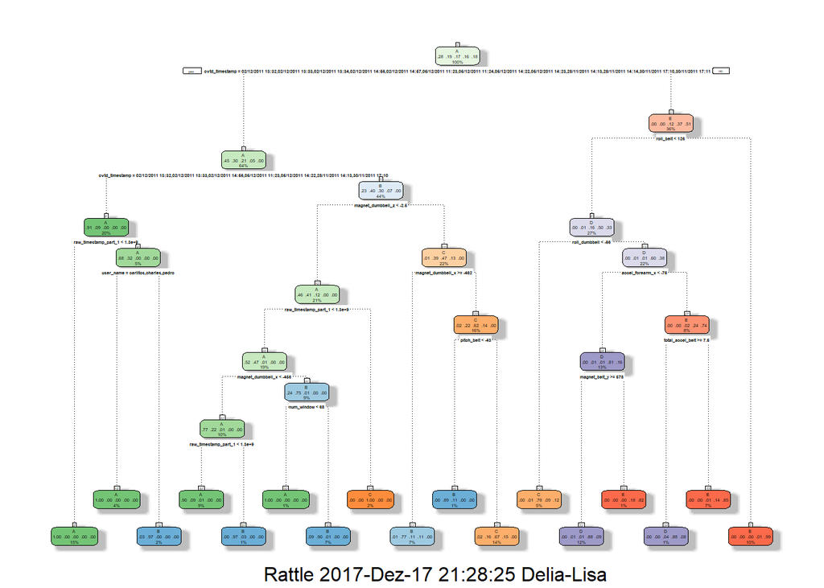

Now evaluate the model using the validation set

```r
predictDT <- predict(modFitDT, newdata = myValSet, type = "class")
conMatDT <- confusionMatrix(predictDT, myValSet$classe)
conMatDT
```

```
## Confusion Matrix and Statistics
##
##           Reference
## Prediction    A    B    C    D    E
##          A 1348   44    3    3    0
##          B   35  787   48   39    0
##          C   12  115  788  113   44
##          D    0    3   10  558   63
##          E    0    0    6   91  794
##
## Overall Statistics
##
##                Accuracy : 0.8717
##                  95% CI : (0.8621, 0.881)
##     No Information Rate : 0.2845
##     P-Value [Acc > NIR] : < 2.2e-16
##
##                   Kappa : 0.8377
##  Mcnemar's Test P-Value : NA
##
## Statistics by Class:
##
##                      Class: A Class: B Class: C Class: D Class: E
## Sensitivity            0.9663   0.8293   0.9216   0.6940   0.8812
## Specificity            0.9858   0.9692   0.9299   0.9815   0.9758
## Pos Pred Value         0.9642   0.8658   0.7351   0.8801   0.8911
## Neg Pred Value         0.9866   0.9594   0.9825   0.9424   0.9733
## Prevalence             0.2845   0.1935   0.1743   0.1639   0.1837
## Detection Rate         0.2749   0.1605   0.1607   0.1138   0.1619
## Detection Prevalence   0.2851   0.1854   0.2186   0.1293   0.1817
## Balanced Accuracy      0.9760   0.8992   0.9257   0.8377   0.9285
```

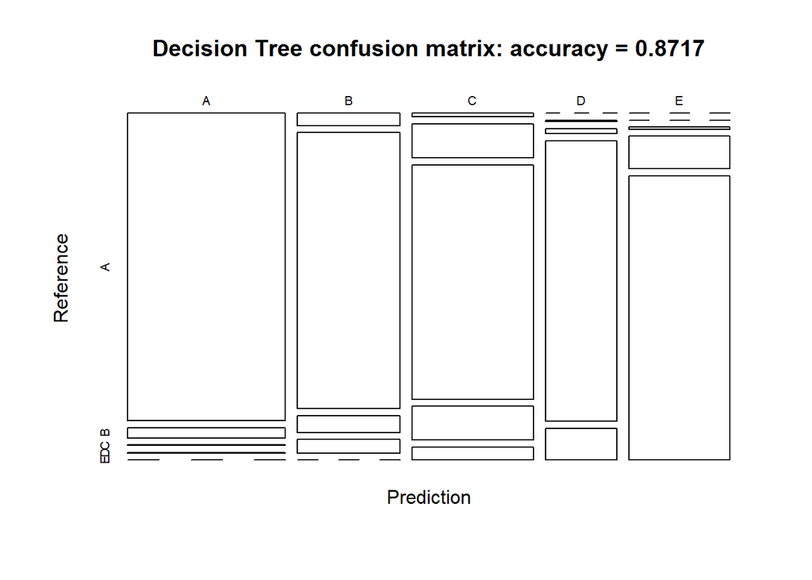

```r
plot(conMatDT$table, col = conMatDT$byClass, main = paste("Decision Tree confusion matrix: accuracy =", round(conMatDT$overall['Accuracy'], 4)))
```

# 2. Prediction with Generalized Boosting Model

```r
set.seed(12345)
controlGBM <- trainControl(method = "repeatedcv", number = 5, repeats = 1)
modFitGBM <- train(classe ~ ., data = myTrainSet, method = "gbm", trControl = controlGBM, verbose = FALSE)
modFitGBM$finalModel
```

```
## A gradient boosted model with multinomial loss function.
## 150 iterations were performed.
## There were 79 predictors of which 43 had non-zero influence.
```

Predict the validation set and plot confusion matrix

```r
predictGBM <- predict(modFitGBM, newdata = myValSet)
conMatGBM <- confusionMatrix(predictGBM, myValSet$classe)
conMatGBM
```

```
## Confusion Matrix and Statistics
##
##           Reference
## Prediction    A    B    C    D    E
##          A 1395    4    0    0    0
##          B    0  942    0    0    0
##          C    0    3  850    1    0
##          D    0    0    5  803    2
##          E    0    0    0    0  899
##
## Overall Statistics
##
##                Accuracy : 0.9969
##                  95% CI : (0.995, 0.9983)
##     No Information Rate : 0.2845
##     P-Value [Acc > NIR] : < 2.2e-16
##
##                   Kappa : 0.9961
##  Mcnemar's Test P-Value : NA
##
## Statistics by Class:
##
##                      Class: A Class: B Class: C Class: D Class: E
## Sensitivity            1.0000   0.9926   0.9942   0.9988   0.9978
## Specificity            0.9989   1.0000   0.9990   0.9983   1.0000
## Pos Pred Value         0.9971   1.0000   0.9953   0.9914   1.0000
## Neg Pred Value         1.0000   0.9982   0.9988   0.9998   0.9995
## Prevalence             0.2845   0.1935   0.1743   0.1639   0.1837
## Detection Rate         0.2845   0.1921   0.1733   0.1637   0.1833
## Detection Prevalence   0.2853   0.1921   0.1741   0.1652   0.1833
## Balanced Accuracy      0.9994   0.9963   0.9966   0.9985   0.9989
```

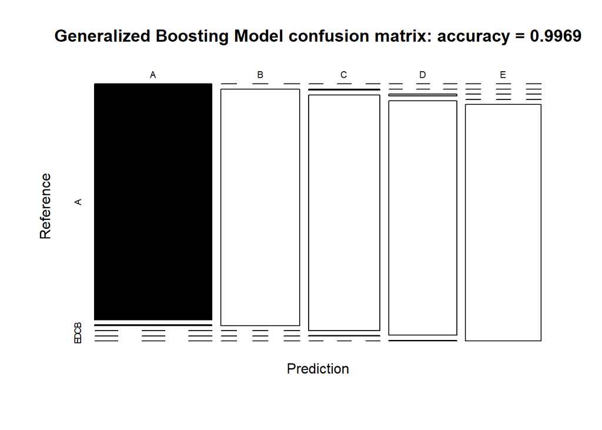

```r
plot(conMatGBM$table, col = conMatGBM$byClass, main = paste("Generalized Boosting Model confusion matrix: accuracy =", round(conMatGBM$overall['Accuracy'], 4)))
```

# 3. Prediction with Random Forest

```r
set.seed(12345)
modFitRF <- randomForest(classe ~ ., data = myTrainSet)
```

Predict using validation set and plot confusion matrix

```r
predictRF <- predict(modFitRF, newdata = myValSet)
conMatRF <- confusionMatrix(predictRF, myValSet$classe)
conMatRF
```

```
## Confusion Matrix and Statistics
##
##           Reference
## Prediction    A    B    C    D    E
##          A 1395    2    0    0    0
##          B    0  947    1    0    0
##          C    0    0  852    0    0
##          D    0    0    2  804    0
##          E    0    0    0    0  901
##
## Overall Statistics
##
##                Accuracy : 0.999
##                  95% CI : (0.9976, 0.9997)
##     No Information Rate : 0.2845
##     P-Value [Acc > NIR] : < 2.2e-16
##
##                   Kappa : 0.9987
##  Mcnemar's Test P-Value : NA
##
## Statistics by Class:
##
##                      Class: A Class: B Class: C Class: D Class: E
## Sensitivity            1.0000   0.9979   0.9965   1.0000   1.0000
## Specificity            0.9994   0.9997   1.0000   0.9995   1.0000
## Pos Pred Value         0.9986   0.9989   1.0000   0.9975   1.0000
## Neg Pred Value         1.0000   0.9995   0.9993   1.0000   1.0000
## Prevalence             0.2845   0.1935   0.1743   0.1639   0.1837
## Detection Rate         0.2845   0.1931   0.1737   0.1639   0.1837
## Detection Prevalence   0.2849   0.1933   0.1737   0.1644   0.1837
## Balanced Accuracy      0.9997   0.9988   0.9982   0.9998   1.0000
```

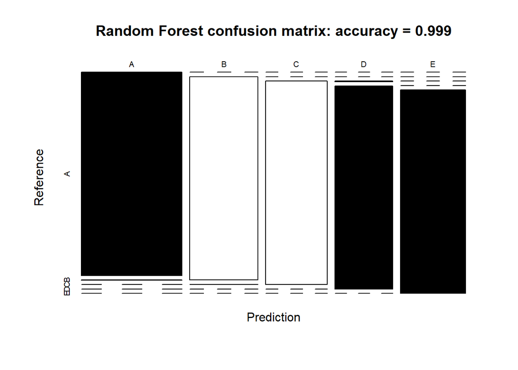

```r
plot(conMatRF$table, col = conMatRF$byClass, main = paste("Random Forest confusion matrix: accuracy =", round(conMatRF$overall['Accuracy'], 4)))
```

## Decision and prediction of the unseen test set

```
## I will choose Random Forest as my prediction model since it yielded the highest accuracy of 0.999 . Thus, I expect an out-of-sample error of 0.102 %.
```

```r
predictTestCases <- predict(modFitRF, newdata = testing)
as.character(predictTestCases)
```

```
##  [1] "B" "A" "B" "A" "A" "E" "D" "B" "A" "A" "B" "C" "B" "A" "E" "E" "A"
## [18] "B" "B" "B"
```